# DSA2101_Group_Project_Rmd

Brandon Neo Bing Jie, Jiang Ruyang, Ng Elangel, Chow Xin Tian

2023-03-24

## DSA2101 Project - Wealth and Income

### Done by: Brandon Neo, Jiang Ruyang, Ng Elangel, Chow Xin Tian

```r
# Get the Data

# Read in with tidytuesdayR package
# Install from CRAN via: install.packages("tidytuesdayR")
# This loads the readme and all the datasets for the week of interest

# Either ISO-8601 date or year/week works!

lifetime_earn <- readr::read_csv('https://raw.githubusercontent.com/rfordatascience/tidytuesday/master/data/2021/2021-02-09/lifetime_earn.csv')
student_debt <- readr::read_csv('https://raw.githubusercontent.com/rfordatascience/tidytuesday/master/data/2021/2021-02-09/student_debt.csv')
retirement <- readr::read_csv('https://raw.githubusercontent.com/rfordatascience/tidytuesday/master/data/2021/2021-02-09/retirement.csv')
home_owner <- readr::read_csv('https://raw.githubusercontent.com/rfordatascience/tidytuesday/master/data/2021/2021-02-09/home_owner.csv')
race_wealth <- readr::read_csv('https://raw.githubusercontent.com/rfordatascience/tidytuesday/master/data/2021/2021-02-09/race_wealth.csv')
income_time <- readr::read_csv('https://raw.githubusercontent.com/rfordatascience/tidytuesday/master/data/2021/2021-02-09/income_time.csv')
income_limits <- readr::read_csv('https://raw.githubusercontent.com/rfordatascience/tidytuesday/master/data/2021/2021-02-09/income_limits.csv')
income_aggregate <- readr::read_csv('https://raw.githubusercontent.com/rfordatascience/tidytuesday/master/data/2021/2021-02-09/income_aggregate.csv')
income_distribution <- readr::read_csv('https://raw.githubusercontent.com/rfordatascience/tidytuesday/master/data/2021/2021-02-09/income_distribution.csv')
income_mean <- readr::read_csv('https://raw.githubusercontent.com/rfordatascience/tidytuesday/master/data/2021/2021-02-09/income_mean.csv')
```

## Introduction

We have analyzed the Wealth and Income dataset, which was provided by the Urban Institute and the US Census, to compare wealth and income over time by race. Some of the key datasets that are relevant to the questions that we seek to investigate in this report are the income distribution and income mean data. The income distribution table provides information about the proportion of the population in each income bracket categorised by race across the years. The income mean table contains data on the mean income earned by each income quintile across the years. To contextualise our findings, we referenced articles on race and income to help explain some of the phenomena.

### Descriptive Statistics

```r
income_distribution_clean = na.omit(income_distribution)
income_distribution_clean = income_distribution_clean %>%
  mutate(race= as.factor(race), income_bracket = as.factor(income_bracket))
```

With all the commotion surrounding increasing wealth inequality between races in the USA, we sought to determine if this is indeed the case. To get an overview of the trend of differences in race wealth in the USA, we used the race_wealth dataset. In our analysis, we first removed all the NA values and filtered the data to display only median family wealth for the races of interest( Blacks and Whites). To compare the difference in median wealth between the two races, we first spread the dataset and subsequently, created a “difference” column. This column shows the difference in median family wealth between the two races throughout the years. From Figure 0.1, the difference in median family wealth is generally increasing from a difference of 92044.93 in 1983 to 153591.00 in 2016. The greatest dive in median family wealth between the Blacks and Whites is around 2007 to 2010 where it fell from 174304.39 in 2007 to 125841.67 in 2010. The fall in difference in median family wealth between the White and the Black is likely due to the 2008 Global Financial Crisis.

#### Figure 0.1

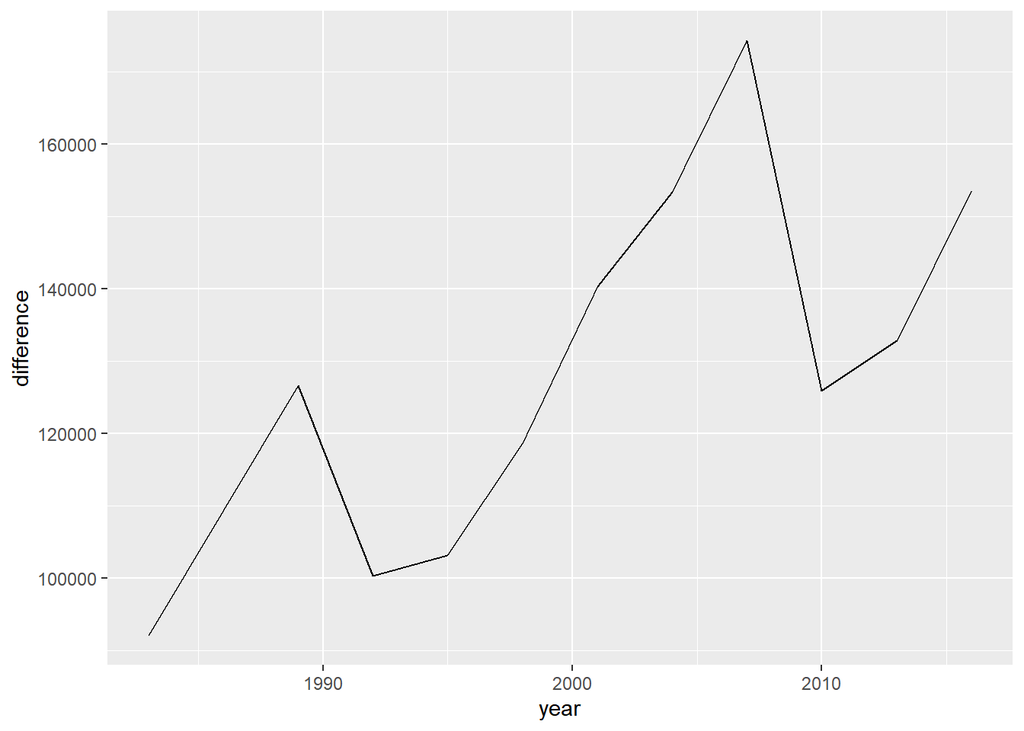

```r
#descriptive stat
wealth = race_wealth %>%
  na.omit()%>%
  filter(type == "Median")%>%
  filter(race == "White" | race == "Black")%>%
  filter(year > 1970)%>%
  spread(race,wealth_family)%>%
  mutate(difference = White - Black)

ggplot(wealth, aes(x = year, y = difference)) +
  geom_line()
```

From the Box and Whisker plot in Figure 0.2, we observe that Asians generally have higher median income as compared to the other races while the Blacks tend to have lower median income as compared to the other races.

#### Figure 0.2

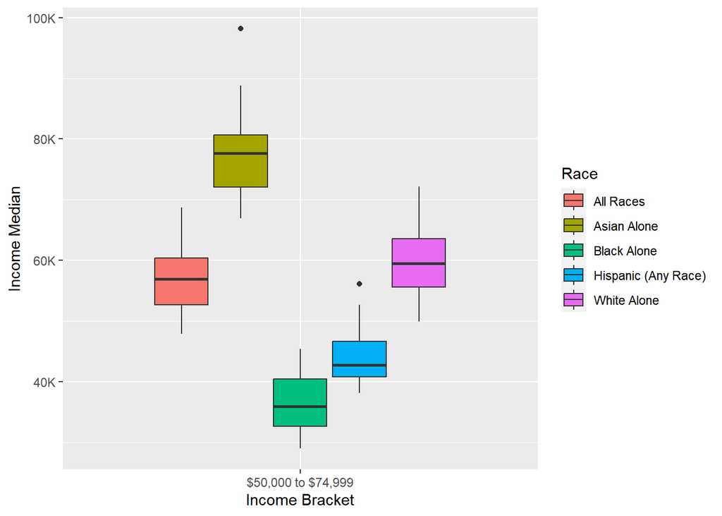

```r
descriptive_stat = income_distribution_clean %>%
  select(year, race, income_median, income_bracket) %>%
  filter(race %in% c("All Races", "White Alone", "Black Alone", "Asian Alone", "Hispanic (Any Race)") & income_bracket == "$50,000 to $74,999") %>%
  mutate(race = as.factor(race), income_bracket = as.factor(income_bracket)) %>%
  rename(Race = race)

ggplot(descriptive_stat, aes(x=income_bracket, y=income_median, fill=Race)) +
  geom_boxplot() +
  labs(x = "Income Bracket", y = "Income Median") +
  scale_y_continuous(labels = scales::label_number_si()) +
  guides(color = guide_legend(title = "Race"))
```

The highest recorded value of the income median throughout history was $98174, which occurred in 2019 while the lowest recorded value of the income median throughout history was $29026 which occurred in 1967.

The number of observations available for Asians was the least among all the other categories of races which could be attributed to the fact that migration was not as prevalent in the 1960s and 1970s since the earliest recorded data available for Asians was only in 1988 in the US.

```r
summary(income_distribution_clean)
```

```
##       year                             race         number
##  Min.   :1967   All Races                :477   Min.   :  1913000
##  1st Qu.:1985   Black Alone              :477   1st Qu.:  7489000
##  Median :1999   White Alone              :477   Median : 17198000
##  Mean   :1997   Hispanic (Any Race)      :432   Mean   : 45310598
##  3rd Qu.:2009   White Alone, Not Hispanic:414   3rd Qu.: 82368000
##  Max.   :2019   Asian Alone              :288   Max.   :128579000
##                 (Other)                  :324
##  income_median   income_med_moe  income_mean     income_mean_moe
##  Min.   :29026   Min.   : 268   Min.   : 34878   Min.   : 287
##  1st Qu.:42073   1st Qu.: 470   1st Qu.: 56812   1st Qu.: 566
##  Median :55575   Median : 795   Median : 67208   Median : 966
##  Mean   :55223   Mean   :1125   Mean   : 72260   Mean   :1380
##  3rd Qu.:64324   3rd Qu.:1293   3rd Qu.: 86838   3rd Qu.:1505
##  Max.   :98174   Max.   :6080   Max.   :133111   Max.   :8076
##
##               income_bracket income_distribution
##  $100,000 to $149,999:321    Min.   : 0.10
##  $15,000 to $24,999  :321    1st Qu.: 8.10
##  $150,000 to $199,999:321    Median :11.00
##  $200,000 and over   :321    Mean   :11.11
##  $25,000 to $34,999  :321    3rd Qu.:14.50
##  $35,000 to $49,999  :321    Max.   :27.20
##  (Other)             :963
```

```r
income_distribution_clean$year[which(income_distribution_clean$income_median == 98174)]
```

```
## [1] 2019 2019 2019 2019 2019 2019 2019 2019 2019
```

```r
income_distribution_clean$year[which(income_distribution_clean$income_median == 29026)]
```

```
## [1] 1967 1967 1967 1967 1967 1967 1967 1967 1967
```

```r
income_distribution_clean %>%
  filter(race == "Asian Alone") %>%
  arrange(year)
```

```
## # A tibble: 288 × 9
##     year race         number income_me…¹ incom…² incom…³ incom…⁴ incom…⁵ incom…⁶
##    <dbl> <fct>         <dbl>       <dbl>   <dbl>   <dbl>   <dbl> <fct>     <dbl>
##  1  1988 Asian Alone 1913000       67230    4545   84053    4130 Under …     8.1
##  2  1988 Asian Alone 1913000       67230    4545   84053    4130 $15,00…     8.7
##  3  1988 Asian Alone 1913000       67230    4545   84053    4130 $25,00…     9
##  4  1988 Asian Alone 1913000       67230    4545   84053    4130 $35,00…    10.9
##  5  1988 Asian Alone 1913000       67230    4545   84053    4130 $50,00…    17.7
##  6  1988 Asian Alone 1913000       67230    4545   84053    4130 $75,00…    14.8
##  7  1988 Asian Alone 1913000       67230    4545   84053    4130 $100,0…    16.9
##  8  1988 Asian Alone 1913000       67230    4545   84053    4130 $150,0…     7.8
##  9  1988 Asian Alone 1913000       67230    4545   84053    4130 $200,0…     6.1
## 10  1989 Asian Alone 1988000       72070    3205   89593    4289 Under …     7.6
## # … with 278 more rows, and abbreviated variable names ¹income_median,
## #   ²income_med_moe, ³income_mean, ⁴income_mean_moe, ⁵income_bracket,
## #   ⁶income_distribution
```

## Question 1: How has racial inequality changed over the years in the United States & what are some potential reasons behind it?

### Introduction:

The income_distribution dataset is used to investigate the question at hand. This dataset provides information on household income based on total money income, race, and Hispanic origin of householders, separated by year and income groups. Our focus is on the median household income of specific racial groups: All Races, Asian Alone, Black Alone, Hispanic (Any Race), and White Alone. By examining changes in the median household income of these racial groups over time, we can gain insight into how the income of households from different racial backgrounds has changed in comparison to the national average (All Races).

### Visualization

#### Question 1 Plot 1 (Figure 1.1)

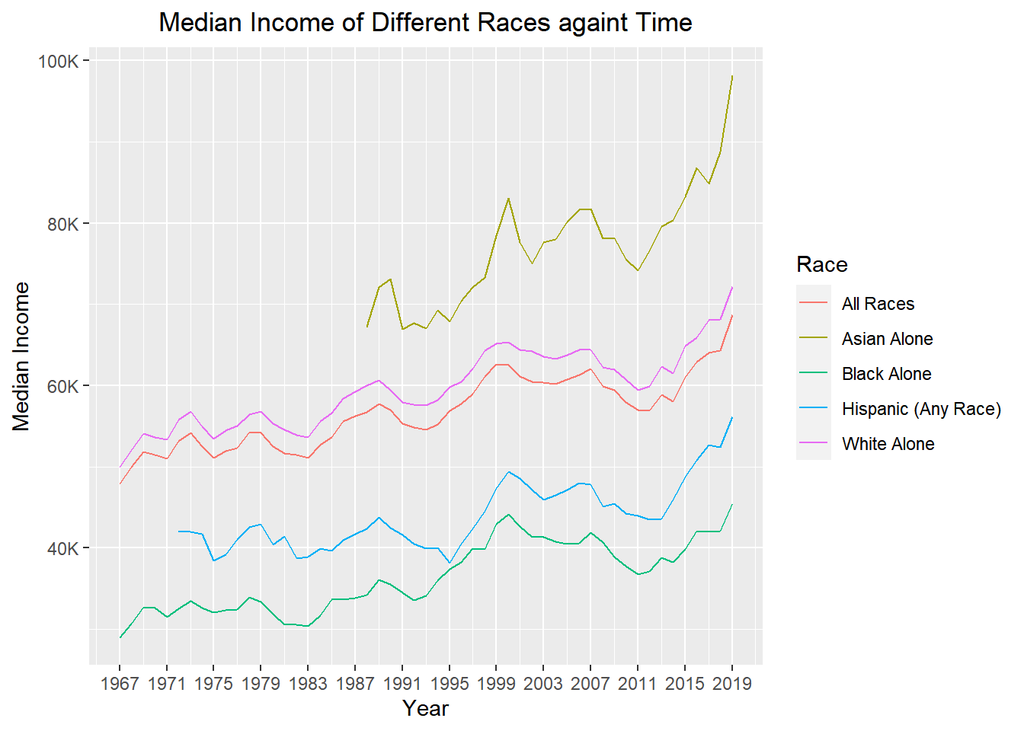

```r
#Median Income of Different Races againt Time
ggplot(descriptive_stat, aes(x=year, y=income_median, color=Race)) +
  geom_line() +
  labs(x = "Year", y = "Median Income",
       title = "Median Income of Different Races againt Time") +
  scale_x_continuous(breaks = seq(min(descriptive_stat$year), max(descriptive_stat$year), 4)) +
  scale_y_continuous(labels = scales::label_number_si()) +
  theme(plot.title = element_text(hjust = 0.5)) +
  guides(color = guide_legend(title = "Race"))
```

##### Black Inequality

```r
all_races_overtime = income_distribution %>%
  filter(race == "All Races" & income_bracket == "$50,000 to $74,999") %>%
  select(year, race, income_median) %>%
  rename(income_median_all_races = income_median)

black_adjusted = income_distribution %>%
  filter(race == "Black Alone" & income_bracket == "$50,000 to $74,999") %>%
  select(year, race, income_median) %>%
  rename(income_median_black = income_median)

black_merged = black_adjusted %>%
  left_join(all_races_overtime, by = "year") %>%
  select(-race.y) %>%
  mutate(inequality = income_median_black - income_median_all_races) %>%
  mutate(pct_inequality = inequality/income_median_all_races)
```

##### White Inequality

```r
white_adjusted = income_distribution %>%
  filter(race == "White Alone" & income_bracket == "$50,000 to $74,999") %>%
  select(year, race, income_median) %>%
  rename(income_median_white = income_median)

white_merged = white_adjusted %>%
  left_join(all_races_overtime, by = "year") %>%
  select(-race.y) %>%
  mutate(inequality = income_median_white - income_median_all_races) %>%
  mutate(pct_inequality = inequality/income_median_all_races)
```

##### Asian Inequality

```r
asian_adjusted = income_distribution %>%
  filter(race == "Asian Alone" & income_bracket == "$50,000 to $74,999") %>%
  select(year, race, income_median) %>%
  rename(income_median_asian = income_median)

asian_merged = asian_adjusted %>%
  left_join(all_races_overtime, by = "year") %>%
  select(-race.y) %>%
  mutate(inequality = income_median_asian - income_median_all_races) %>%
  mutate(pct_inequality = inequality/income_median_all_races)
```

##### Hispanic Inequality

```r
hispanic_adjusted = income_distribution %>%
  filter(race == "Hispanic (Any Race)" & income_bracket == "$50,000 to $74,999") %>%
  select(year, race, income_median) %>%
  rename(income_median_hispanic = income_median)

hispanic_merged = hispanic_adjusted %>%
  left_join(all_races_overtime, by = "year") %>%
  select(-race.y) %>%
  mutate(inequality = income_median_hispanic - income_median_all_races) %>%
  mutate(pct_inequality = inequality/income_median_all_races)
```

#### Question 1 Plot 2 (Figure 1.2)

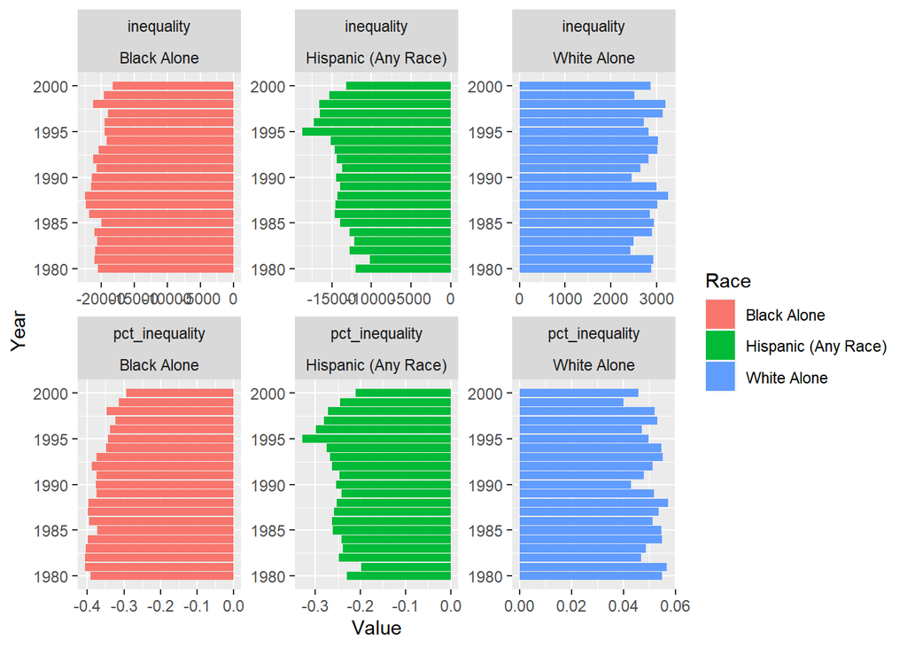

```r
#using facet_wrap to plot side by side graphs comparison
black_facetplot = black_merged %>%
  filter(year >= 1980 & year <= 2000) %>%
  rename(race = race.x) %>%
  select(year, race, inequality, pct_inequality)

white_facetplot = white_merged %>%
  filter(year >= 1980 & year <= 2000) %>%
  rename(race = race.x) %>%
  select(year, race, inequality, pct_inequality)

hispanic_facetplot = hispanic_merged %>%
  filter(year >= 1980 & year <= 2000) %>%
  rename(race = race.x) %>%
  select(year, race, inequality, pct_inequality)

facetplot_df = rbind(black_facetplot, white_facetplot, hispanic_facetplot)


facet_wrap_plot = facetplot_df %>%
  gather(key=measures, value = "Value", c("inequality", "pct_inequality")) %>%
  rename(Race = race, Year = year)


#Facet Plot
ggplot(facet_wrap_plot, aes(x=Year, y=Value, fill=Race)) +
  geom_bar(stat="identity") +
  coord_flip() +
  facet_wrap(measures ~ Race, scales="free")
```

### Discussions:

From the first plot (Figure 1.1), it is evident that the median income of all racial groups in the United States has increased from 1967 to 2019. However, the data also highlights that particular racial groups, namely Hispanic (Any Race) and Black Alone, have consistently faced lower median income compared to the overall median income for all races. Conversely, certain racial groups, such as Asian Alone and White Alone, have consistently received higher income than the population median income. Thus, to further study this income difference between racial groups, we zoom in to look at the income inequality faced by different racial groups from 1980 to 2000.

This is supported by our second plot (Figure 1.2). We observe that in Figure 1.2, income inequality generally improves for the Blacks, as the percentage inequality has bcomes more positive from the 1980s to the 2000s. From the 1980s to 2000s, the Blacks have become increasingly more educated. (Hoffman, 2004) Black entrants to the labour market were thus found to have higher levels of skill allowing them to take up more complex, higher paying jobs. This leads to an increase in median wages for the Blacks. Although the Hispanic population has experienced similar progress in educational inclusivity, they appear to exhibit a slower pace of advancement in addressing income inequality. This may be due to the significant number of Latino immigrants who have migrated to the United States from 1980s to 2000s and taken up low-paying, low-skilled jobs.

## Question 2: How has class inequality evolved in the US throughout the years and what are some of the potential causes of this phenomenon?

### Introduction:

The purpose of this inquiry is to examine the impact of class division on income inequality in the United States. To investigate the class divide, we will utilize the data set “income_mean,” which presents the average income earned by each quintile and the top 5% of individuals from various racial groups. Our aim is to investigate the relationship between class division and problem 1. This is so that we can determine whether class division or racial division is the primary cause of inequality in the United States.

### Methodology:

The first visualisation (Figure 2.1) is the change in income over the years with respect to each income bracket. We plot the mean income of different income brackets (i.e. “Top 5%”, “Highest Quintile”, and “Lowest Quintile”) of all races across the year in the US. This gives us a time-series plot with 6 different lines. This plot is effective in visualising how the mean income of different income groups have changed over the years. In the second visualisation (Figure 2.2) , we compared the change in decile ratio between the races in 1980 and in 2015. To measure income inequality, we made use of the decile ratio which compares the income of the top 20% earners in the population to the income of the bottom 20% earners. We calculated the decile ratio using the formula:

Decile Ratio = Mean Income of the Richest 20% / Mean Income of the Poorest 20%

We made use of a bar plot to illustrate this relationship because we are interested in comparing how the decile ratios have changed over the two selected time frames for different races. The bar plot serves as a useful tool in this scenario because we are able to segment each race according to different bars in the plot.

### Visualizations

#### Question 2 Plot 1 (Figure 2.1)

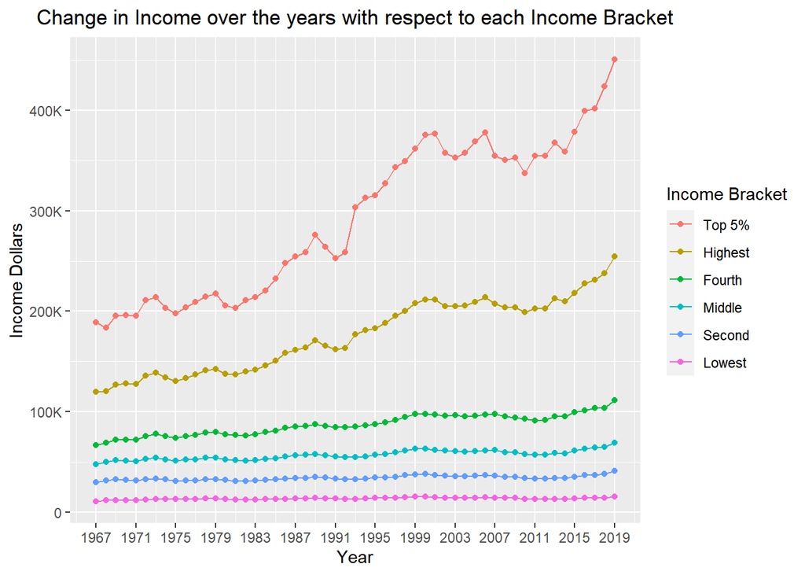

```r
income_class = income_mean %>%
  filter(race == "All Races" & dollar_type == "2019 Dollars")

ggplot(income_class, aes(x=year, y=income_dollars, color=income_quintile)) +
  geom_point() +
  geom_line() +
  labs(x = "Year", y = "Income Dollars" ,
       title = "Change in Income over the years with respect to each Income Bracket") +
  scale_x_continuous(breaks = seq(min(income_class$year), max(income_class$year), 4)) +
  scale_y_continuous(labels = scales::label_number_si()) +
  scale_color_discrete(limits=c("Top 5%", "Highest",  "Fourth", "Middle", "Second", "Lowest")) +
  guides(color = guide_legend(title = "Income Bracket")) +
  theme(plot.title = element_text(hjust = 0.5))
```

#### Question 2 Plot 2 (Figure 2.2)

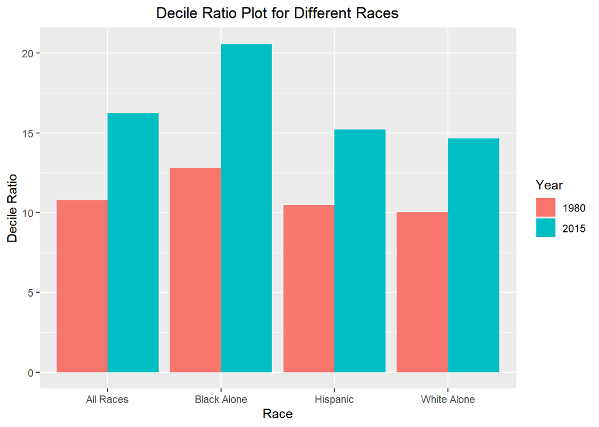

```r
#All Races
decile_2015_all = income_mean %>%
  filter((year == 2015) & dollar_type == "2019 Dollars" & race == "All Races") %>%
  filter(income_quintile == "Lowest" | income_quintile == "Highest") %>%
  spread(key = income_quintile, value = income_dollars) %>%
  mutate(decile_ratio = Highest/Lowest)

decile_1980_all = income_mean %>%
  filter((year == 1980) & dollar_type == "2019 Dollars" & race == "All Races") %>%
  filter(income_quintile == "Lowest" | income_quintile == "Highest") %>%
  spread(key = income_quintile, value = income_dollars) %>%
  mutate(decile_ratio = Highest/Lowest)

#Black
decile_2015_black = income_mean %>%
  filter((year == 2015) & dollar_type == "2019 Dollars" & race == "Black Alone") %>%
  filter(income_quintile == "Lowest" | income_quintile == "Highest") %>%
  spread(key = income_quintile, value = income_dollars) %>%
  mutate(decile_ratio = Highest/Lowest)

decile_1980_black = income_mean %>%
  filter((year == 1980) & dollar_type == "2019 Dollars" & race == "Black Alone") %>%
  filter(income_quintile == "Lowest" | income_quintile == "Highest") %>%
  spread(key = income_quintile, value = income_dollars) %>%
  mutate(decile_ratio = Highest/Lowest)

#White
decile_2015_white = income_mean %>%
  filter((year == 2015) & dollar_type == "2019 Dollars" & race == "White Alone") %>%
  filter(income_quintile == "Lowest" | income_quintile == "Highest") %>%
  spread(key = income_quintile, value = income_dollars) %>%
  mutate(decile_ratio = Highest/Lowest)

decile_1980_white = income_mean %>%
  filter((year == 1980) & dollar_type == "2019 Dollars" & race == "White Alone") %>%
  filter(income_quintile == "Lowest" | income_quintile == "Highest") %>%
  spread(key = income_quintile, value = income_dollars) %>%
  mutate(decile_ratio = Highest/Lowest)


#Hispanic
decile_2015_hispanic = income_mean %>%
  filter((year == 2015) & dollar_type == "2019 Dollars" & race == "Hispanic") %>%
  filter(income_quintile == "Lowest" | income_quintile == "Highest") %>%
  spread(key = income_quintile, value = income_dollars) %>%
  mutate(decile_ratio = Highest/Lowest)

decile_1980_hispanic = income_mean %>%
  filter((year == 1980) & dollar_type == "2019 Dollars" & race == "Hispanic") %>%
  filter(income_quintile == "Lowest" | income_quintile == "Highest") %>%
  spread(key = income_quintile, value = income_dollars) %>%
  mutate(decile_ratio = Highest/Lowest)


#Merged for Decile Plotting
decile_all = rbind(decile_2015_all, decile_1980_all)
decile_black = rbind(decile_2015_black, decile_1980_black)
decile_white = rbind(decile_2015_white, decile_1980_white)
decile_hispanic = rbind(decile_2015_hispanic, decile_1980_hispanic)
decile_final = rbind(decile_all, decile_black, decile_white, decile_hispanic)

ggplot(decile_final, aes(x = race, y = decile_ratio, fill = factor(year))) +
         geom_bar(stat = "identity", position = position_dodge()) +
         labs(x = "Race", y = "Decile Ratio", fill = "Year") +
         ggtitle("Decile Ratio Plot for Different Races") +
         theme(plot.title = element_text(hjust = 0.5))
```

### Discussions:

From the 2 plots, we can conclude that the mean income gap has widened over the years. This is not surprising as it has been a clear trend among most of the countries where the rich are getting richer. The sheer scale of the wealth of the rich means that they are more likely to earn more from their investment, both the high-risk and low-risk ones. When considering a specific portfolio allocation, individuals with greater wealth are more likely to receive higher risk-adjusted returns, potentially due to their access to exclusive investment opportunities or superior wealth management services. These attributes contribute to the persistent returns on wealth observed over time. (Malacrino, 2020)

### Exogeneous Limitations:

In our analysis, we have chosen to only look at the data corresponding to non-mixed races as we acknowledge from the author of the data set that there is inherently double counting of observations for overlapping mixed and unmixed races. We have chosen to exclude the Asian race in our decile ratio plot as the earliest data we have for Asians in the income mean dataset dates back to 2002. We feel that the timeframe between 2002 and 2015 is too short for us to explain any possible trends. Therefore, our analysis and conclusions are limited to non-mixed races and non-Asians and may not be fully representative of class inequality in the US.

### References:

- Gregory, J. (2015). Latinx Great Migrations - History and Geography. Civil Rights and Labour History Consortium, University of Washington. Retrieved April 14, 2023, from https://depts.washington.edu/moving1/latinx_migration.shtml
- Hoffman, K., & Llagas, C. (2004). Status and trends in the education of blacks. PsycEXTRA Dataset. https://doi.org/10.1037/e609922011-020
- Kerner, O., & Kerner, O. (1968). Introduction. In Report of the National Advisory Commission on civil disorders (pp. 1–29). introduction, For sale by the Supt. of Docs., U.S. Govt. Print. Off. Orfield, G., & Jarvie, D. (2020). (rep.). BLACK SEGREGATION MATTERS. Retrieved April 11, 2023, from https://www.civilrightsproject.ucla.edu/research/k-12-education/integration-and-diversity/black-segregation-matters-school-resegregation-and-black-educational-opportunity/BLACK-SEGREGATION-MATTERS-final-121820.pdf.
- Smith, T. M. (1995). (rep.). THE EDUCATIONAL PROGRESS OF BLACK STUDENTS. Retrieved April 11, 2023, from https://nces.ed.gov/pubs95/95765.pdf.
- Malacrino, D. (2020, November 30). How the Rich Get Richer. IMF. Retrieved April 11, 2023, from https://www.imf.org/en/Blogs/Articles/2020/11/30/how-the-rich-get-richer
- Rfordatascience, jonthegeek. (2022, November 30). Tidytuesday/readme.md at master · rfordatascience/tidytuesday. GitHub. Retrieved April 11, 2023, from https://github.com/rfordatascience/tidytuesday/blob/master/data/2021/2021-02-09/readme.md
- Status and trends in the education of Blacks - National Center for … (n.d.). Retrieved April 11, 2023, from https://nces.ed.gov/pubs2003/2003034.pdf
- Black Segregation Matters - University of California, Los Angeles. (n.d.). Retrieved April 11, 2023, from https://www.civilrightsproject.ucla.edu/research/k-12-education/integration-and-diversity/black-segregation-matters-school-resegregation-and-black-educational-opportunity/BLACK-SEGREGATION-MATTERS-final-121820.pdf
- REPORT OF THE NATIONAL ADVISORY COMMISSION ON CIVIL DISORDERS. (n.d.). Retrieved from http://www.eisenhowerfoundation.org/docs/kerner.pdf